https://doi.org/10.1007/s00213-021-05960-2

**REVIEW**

**Co‑exposure of cannabinoids with amphetamines and biological,**

**behavioural and health outcomes: a scoping review of animal**

**and human studies**

**Dimitri Daldegan‑Bueno**<sup>**1**</sup> **· Lucas O. Maia**<sup>**2**</sup> **· Michelle Glass**<sup>**3**</sup> **· Didier Jutras‑Aswad**<sup>**4,5**</sup> **· Benedikt Fischer**<sup>**1,2,6,7**</sup>

Received: 1 March 2021 / Accepted: 2 August 2021

© The Author(s) 2021

**Abstract**

**Rationale** The growing prevalence of psychostimulant (including amphetamine) use and associated health harms, with

limited treatment options, present a global challenge. There is an increasing availability and medical applications of can-

nabinoids, and growing interest in their therapeutic potential for addictive disorders.

**Objectives** The objective of this study is to review available data regarding cannabis/cannabinoid co-use or exposure on

amphetamine-related outcomes.

**Methods** Towards the present scoping review, we systematically searched four databases (Medline, Web-of-Science,

CINAHL Plus and PsycInfo) using cannabis/cannabinoid and amphetamine text-terms identifying peer-reviewed, English-

language studies published in 2000–2020 involving multiple methods approaches among both human and animal study sam-

ples, assessing the association of co-use/administration of cannabis/cannabinoids products with non-medical amphetamines

on biological, behavioural or health outcomes.

**Results** Twenty-five articles were included. Pre-clinical studies (*n* = 15) found mostly protective effects of single or repeated

cannabinoids administration on rodents in amphetamine addiction models, amphetamine-induced models of human mental

disorders (e.g. schizophrenia) and amphetamine-induced neurotoxicity. Human studies (*n* = 10) were more heterogeneously

designed (e.g. cross-sectional, case–control, longitudinal) and assessed natural ongoing cannabis and methamphetamine use or

dependence, showing mostly enhanced harms in a diversity of outcomes (e.g. mental health, methamphetamine use, cognition).

**Conclusions** While human studies suggest cannabis use as an adverse risk factor among non-medical amphetamine users,

pre-clinical studies suggest therapeutic potential of cannabinoids, especially cannabidiol, to alleviate amphetamine addic-

tion and harms, including treatment outcomes. Given increasing psychostimulant harms but lack of care options, rigorous,

high-quality design studies should aim to translate and investigate pre-clinical study results for potential therapeutic benefits

of cannabinoids for amphetamine use/abuse in human subjects.

**Keywords** Amphetamines · Cannabis · Cannabinoids · Cannabidiol · Co-use · Exposure · Tetrahydrocannabinol ·

Translational research · Addictive behaviour · Review

**Introduction**

A 0.5% (approximately 27 million people) of the world’s

adult population use amphetamines, a central nervous sys-

tem stimulant. Of these users, approximately 6.6 million

(86/100,000 population) are estimated to be dependent,

rendering amphetamine substances to be among the most

used illicit drugs globally (Degenhardt et al. 2013; Peacock

et al. 2018; UNODC 2020). Extra-medical amphetamine

use, especially methamphetamine (a more potent structural

form (Lake and Quirk 1984)), is associated with elevated

risks for both mortality and morbidity outcomes, including

acute poisoning, mental health (e.g. depression, psychosis,

suicidal behaviours) and neurocognitive impairments, car-

diovascular problems, injury and violence (Cumming et al.

2020; Marshall and Werb 2010; Marshall et al. 2011; McKe-

tin et al. 2019; Wood et al. 2006). Amphetamine dependence

This article belongs to a Special Issue on Cannabis and

Cannabinoids

*<sup>Benedikt Fischer</sup>

bfischer@sfu.ca

Extended author information available on the last page of the article

/ Published online: 6 October 2021

Psychopharmacology (2022) 239:1211–1230

was responsible for about 0.6% (approximately 326,000

deaths) of global all-cause mortality in 2017, entailing a

mortality risk among people with amphetamine dependence

up to six times higher than the general population (Farrell

et al. 2019). Changes in illegal drug production patterns sug-

gest that amphetamines supply and use have been globally

increasing. Global methamphetamine seizures increased by

16% in 2015/16; despite seizures occurring mainly in North

America and Asia, a 50% increase of countries reporting

seizures has been observed in the last decade. The major-

ity (90%) of dismantled methamphetamine laboratories are

located in North America, with the USA harbouring most

of these (3,036 or 82%) worldwide in 2017 — mostly sup-

plying the local market (i.e. “kitchen lab”) in contrast with

large-scale, export-oriented laboratories in Mexico and East/

South-East Asia (Farrell et al. 2019; UNODC 2020).

Currently, there are no pharmacotherapeutic

options approved for the treatment of stimulant use disor-

der, including amphetamines, at any of the main stages of

treatment (e.g. withdrawal, relapse prevention) (Brandt et al.

2020; Castells et al. 2016; Morley et al. 2017; Pérez-Mañá

et al. 2013; Ronsley et al. 2020; Siefried et al. 2020; Tar-

delli et al. 2020). The range of evidence-based, non-phar-

macotherapeutic treatment or targeted prevention measures

is overall highly limited, although select cognitive-behav-

ioural interventions, including contingency management

approaches, have shown some promise (Cumming et al.

2016; Fischer et al. 2015a; Knapp et al. 2007; Lee and Raw-

son 2008; Minozzi et al. 2016; Shearer 2007). This situa-

tion underscores a need for the examination of potentially

effective therapeutic strategies or interventions for psycho-

stimulant and specifically problematic amphetamine use

or use disorders (Fischer et al. 2015b; Kogan and Mech-

oulam 2007; Shorter et al. 2015). Recently, there has been

increased focus on the endocannabinoid system as a possible

target for treating drug dependence, craving or withdrawal

(Chye et al. 2019; Manzanares et al. 2018; Parsons and Hurd

2015; Spanagel 2020), with a growing number of studies

examining the therapeutic effects of cannabinoid agents for

addictive disorders (Batalla et al. 2019; Calpe-López et al.

2019; Prud'homme et al. 2015; Turna et al. 2019).

The endocannabinoid system (ECS) is a central bio-

logical system composed of at least two endocannabinoids

(neurotransmitters; anandamide and 2-arachidoyl glycerol)

that bind to cannabinoid receptors expressed throughout the

mammalian vertebrate central and peripheral nervous sys-

tems. The ECS is centrally involved in regulating essential

neural, physiological and cognitive processes, including

movement control and motor coordination, learning and

memory, mood, stress response and motivation, the immune

system, appetite, addictive behaviours and pain modulation,

among others (Cabral et al. 2015; Kruk-Slomka et al. 2017;

Lu and Mackie 2021; Mechoulam and Parker 2013). The

ECS is also involved in key brain structures (e.g. prefrontal,

limbic, striatal) and neurotransmitter systems (e.g. sero-

tonin, dopamine) essential in the reward system and drug

addiction. Of special interest is the role of CB1 receptors,

expressed in brain regions involved in decision-making,

withdrawal and relapse, and therefore, essential for modu-

lating the rewarding effects of drugs (Chye et al. 2019; Mal-

donado et al. 2006; Manzanares et al. 2018; Parsons and

Hurd 2015; Spanagel 2020). Moreover, there is increasing

evidence and practice of medical usage for some indications

(e.g. neuropathic pain, chemotherapy-induced nausea — for

reviews see (Abrams 2018; Crippa et al. 2018; NASEM

2017)) and legal availability of cannabinoids products in

many countries. Related, a purified cannabis-derived pre-

scription form of cannabinoid has been recently approved in

Europe and the USA for selected medical usage indications

(GlobeNewswire 2020, 2021; Marcu 2020). Possibly benefi-

cial effects or properties from cannabinoids agents specifi-

cally for addictive behaviours related to various substance

groups (e.g. opioids, alcohol, nicotine, other stimulants)

have been suggested, but no conclusive (e.g. clinical trial-

based) evidence or reviews for amphetamine use and related

problems presently exist (Abrams 2018; Prud'homme et al.

2015). On this basis, we sought to comprehensively review

the existing, multidisciplinary studies and outcome data that

have investigated the associations of cannabinoid exposure

on amphetamine use and adverse outcomes in different study

populations.

**Methods**

**Study aim and scope**

We conducted a scoping review which aimed to identify

and summarize data on possible associations of natural or

experimental co-administration of cannabinoids on ampheta-

mine use-related biological, behavioural or health outcomes

from different methodological or disciplinary approaches

(e.g. pre-clinical, human experimental, observational stud-

ies). Cannabinoids were defined to include all-natural canna-

bis product forms or compositions (e.g. cannabidiol [CBD],

tetrahydrocannabinol [THC]) and amphetamine products

referred to both amphetamines and the structurally similar

methamphetamines. Both cannabinoids and amphetamines

were considered irrespective of way of use (e.g. smoke, oral

ingestion) or user status (e.g. dependence); while canna-

bis was considered regardless of the intended purpose of

use (e.g. medical, non-medical); only extra-medical use of

amphetamines was considered. Considering the over-time

evolution in amphetamine-type drug use, types of can-

nabis products available and the fact that the potential of

cannabinoids for addiction-related outcomes has only been

investigated more recently (Fischer et al. 2015b), we limited

our search to studies published since 2000 with a goal of

providing a comprehensive review of relatively recent stud-

ies and data.

**Search strategy**

The systematic search strategy applied was originally

developed for MEDLINE through an iterative process by

the co-authors; the final search strategy was revised and

adjusted using the Peer Review Electronic Search Strategies

(PRESS) checklist (McGowan et al. 2016) and translated to

other databases. Four databases were accessed: MEDLINE

(PubMed), Web of Science (core collection), CINAHL plus

and PsycInfo. The search strategy focused on related can-

nabis/cannabinoid and amphetamine text words based on

MeSH indexing terms (e.g. marijuana, cannabis, CBD, THC,

amphetamine, methamphetamine). Given the broad scope

and high heterogeneity/interdisciplinarity of study data spe-

cifically for outcomes comprised by our scoping review and

the intent to comprehensively capture and document these,

we did not limit the search by specific outcome terms to

avoid a potential restriction, or loss of relevant studies or

data. Rather, we left the search for, and identification of,

any relevant outcomes as defined by the scope of the review

to the subsequent title/abstract and content screening. The

full strategy details are presented as supplementary material.

Complementary search strategies included comprehensive

hand-searching of the reference lists of included studies. The

results from the multiple databases were collated and de-

duplicated using the Systematic Review Assistant-Dedupli-

cation Module (SRA-DM) (Rathbone et al. 2015) and then

uploaded to Endnote (v.X9.2), where all screening manage-

ment tasks were performed.

**Study screening and selection**

Study screening and selection were based on the follow-

ing inclusion criteria: (1) original articles based on primary

study data; (2) studies examining the direct/immediate,

recent (i.e. prior 3 months in humans or same life-phase

in animals [e.g. adults, adolescents]), or lifetime (of active

users) co-use or co-exposure of cannabinoid products with

amphetamine products in human or animal populations; (3)

reporting biological, behavioural or health-related meas-

ures or outcomes (e.g. brain activity/function, craving, drug

use/dependence); (4) with measures or outcomes available

that somehow comparatively attributed to amphetamine-

only use or groups versus amphetamine and cannabinoid

co-use or co-exposure; and (5) in English-language studies

published since 2000 to 28 October 2020. Following de-

duplication, titles and abstracts were screened by one lead

reviewer (DDB), with potentially unclear or ambiguous

cases identified and arbitrated towards consensus together

with a second reviewer (BF), followed by full-text review

of studies identified for possible inclusion by the same pro-

cedure. We excluded studies that did not meet the above

criteria, as well as reviews, commentaries, case reports and

case–control studies that mixed amphetamine- or cannab-

inoid-related data with other non-target drug use in study

groups. To assess the eligibility of case–control studies for

inclusion, we verified the exclusive presence of data for

amphetamine use with/without cannabinoid use groups and

attributable outcomes through information from the stud-

ies’ methods and results sections. Abstracts or full studies

excluded predominantly did not match the content- or out-

come-specific criteria for the review (e.g. no clear cannabis/

amphetamine comparison, no current cannabis use) or could

not be accessed. The attached flowchart (Fig. 1) presents the

main process steps for the present review.

**Data presentation**

Given the aim of a comprehensive, scoping review com-

prising evidence from multi-disciplinary perspectives, both

quantitative and qualitative types of studies in different

population/samples (e.g. animal, human experimental, treat-

ment, community) were included. For results documenta-

tion, we used a descriptive approach, inductively grouping

studies principally by type of basic study population and

methods/approach, further dividing into study sub-cluster,

and narratively summarizing the essential study scope,

measures and results. As is common for a scoping review,

no risk of bias or quality assessment (Arksey and O'Malley

2005) and no meta-analyses (also due to the heterogeneity

of study designs and outcomes) were conducted.

**Results**

**Characteristics of included studies**

Overall, 6,705 article citations were identified from the data-

base searches which, after deduplication, resulted in a total

of 3,237 potentially relevant abstracts that were screened.

From these, 48 abstracts were selected for full-text review,

with the final 25 articles included in the present review

experimental models (*n* = 15) and human population (*n* = 10)

studies. Animal studies involved rodents (rats or mice)

experiments of THC or CBD (single or repeat) administra-

tion compared to controls (i.e. vehicle administration). On

the basis of the data, studies were divided into three clusters:

non-contingent models of addiction (e.g. conditioned place

preference and sensitization experiments) (*n* = 6), contingent

models of addiction (drug self-administration experiments)

(*n* = 3) and amphetamine-induced human mental health

models and neurotoxicity experiments (*n* = 6). Human pop-

ulation studies comprised methamphetamine and cannabis

users or dependents within small or larger population sam-

ple. Study designs were cross-sectional (e.g. case–control,

experimental intervention), prospective and longitudinal

with biological, psycho-behavioural and mental health- or

addiction-related outcomes, organized into three topical

study clusters: brain structure/metabolism (*n* = 3), neuropsy-

chological function or psychopathology symptoms (*n* = 3)

and methamphetamine use patterns (*n* = 4). See Tables 1 and

2 for animal and human studies summaries.

**Pre‑clinical studies in animals**

**Non‑contingent models of addiction (n = 6)**

Four vehicle-controlled studies investigated the effects of

single CBD or THC administration in rats with an ampheta-

mine- or methamphetamine-conditioned place preference

(i.e. preference to a drug-paired environment) on amphet-

amine-reinstatement (i.e. return of drug-seeking after

extinction of drug-seeking behaviour) and neurobiological

outcomes. THC (0.5 mg/kg, i.p.) or CBD (5 mg/kg, i.p.)

administration 30 min before amphetamine place preference

extinction trials (*n* = 8–12/group) potentiated the extinction

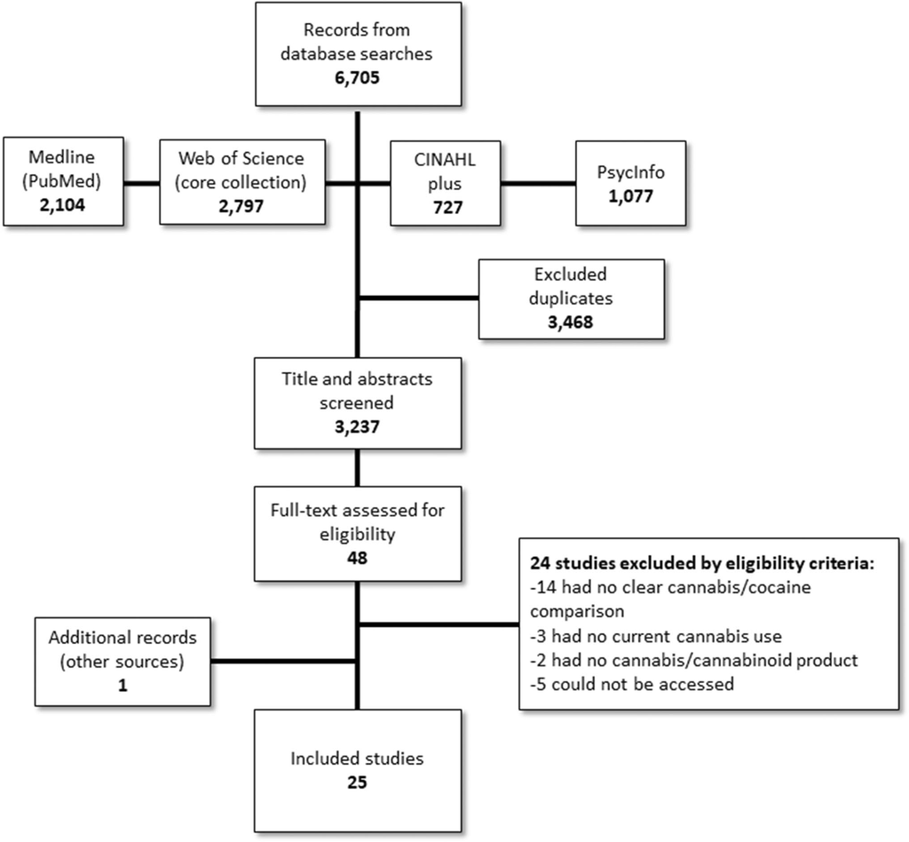

**Fig. 1** Flowchart of the selection process of studies.

1214

Psychopharmacology (2022) 239:1211–1230

1 3

**Table 1** Summary of pre-clinical studies with cannabinoids and amphetamine co-administration

Study

Sample

(sample size)

Cannabinoid

Intervention/design

Outcome measures

Pattern of cannabinoid

administration

Main results

**Non-contingent models of addiction**

Yang et al., 2020

Rats

(3–10/group)

CBD

10, 20, 40, and 80 mg/

kg, i.p

Effects of CBD exposure on

METH-induced conditioned

place preference (vehicle-

controlled study)

METH-induced

conditioned place

preference and

brain signalling

pathways

Single CBD administration

during METH-induced

conditioning place prefer-

ence, 1 h before METH

administration

↑ CBD reduced METH

place preference in a

dose-dependent manner

(*p* < 0.05) and decreased

METH-induced pathways

(e.g. Sigma1 recep-

tor, p-AKT, p-GSK-3β,

p-CREB) levels in the

prefrontal cortex, nucleus

accumbens, hippocampus,

and ventral tegmental area

(*p* < 0.05)

Karimi-Haghighi et al.,

2020

Rats

(4–5/group)

CBD

10 µg/5 µl, i.c.v

Effects of CBD exposure

on neuroinflammatory

factors during METH- and

stress-induced METH-

reinstatement

Neuroinflammatory

factors (e.g. IL‐1β,

IL‐6, IL‐10, TNF)

in the prefrontal

cortex and hip-

pocampus

After METH-self admin-

istration extinction,

single CBD administration

60 min before METH-

induced reinstatement

in sleep deprived/non-

deprived animals

↔ CBD reduced neuroin-

flammatory factors expres-

sion in the prefrontal cortex

and hippocampus in the

METH-induced reinstate-

ment group (*p* < 0.05), but

augmented in the hip-

pocampus of the sleep-

deprived group (*p* < 0.05)

Karimi-Haghighi & Hagh-

parast, 2018

Rats

(4–6/group)

CBD

10 µg/5 µl

i.c.v

Effects of CBD exposure on

METH-reinstatement in

sleep deprived rats (vehicle-

controlled study)

METH-induced

reinstatement

After METH-self admin-

istration extinction,

single CBD administration

60 min before METH–

induced reinstatement

in sleep deprived/non-

deprived animals

↑ CBD reduced METH-

induced reinstatement

in sleep and non-sleep

deprived animals (*F*(3,

22) = 11.13, *p* < 0.001; *F*(2,

15) = 18.29, *p* < 0.001)

Ellgren et al., 2004

Rats

(6–8/group)

THC

0.75, 1.5 and 3.0 mg/kg

i.p

Effects of THC exposure on

AMPH-sensitization in dif-

ferent ages

(vehicle-controlled study)

AMPH-sensitization

in adolescent and

adult rats

Daily THC administration

for five days, 7 or 35 days

before AMPH administra-

tion

↔ THC had no effect on

AMPH-sensitization neither

in adolescents nor in adults

(*F*(3, 97) = 31.2, *p* < 0.001;

*F*(4, 95) = 23.2, *p* < 0.001)*

Parker et al., 2004

Rats

(8–12/group)

CBD

(5 mg/kg) or

THC

(0.5 mg/kg), i.p

Effects of CBD or THC

exposure on the extinction

of AMPH place preference

memory (vehicle-controlled

study)

Extinction of AMPH-

induced place

preference

Single CBD or THC admin-

istration 30 min before

METH-induced place

preference training

↑ CBD and THC potentiated

the extinction of AMPH-

induced place-preference

learning (F(3, 32) = 4.7,

*p* < 0.01)

1215

Psychopharmacology (2022) 239:1211–1230

1 3

**Table 1** (continued)

Study

Sample

(sample size)

Cannabinoid

Intervention/design

Outcome measures

Pattern of cannabinoid

administration

Main results

Lamarque et al., 2001

Rats

(9–12/group)

THC

0.6, 3 and 15 mg/kg

i.p

Effects of THC exposure

on AMPH-sensitization

(vehicle-controlled study)

AMPH-sensitiza-

tion in high- or

low-locomotion

responsive-animals

Twenty-seven THC adminis-

trations in a 3-week period,

3 and 55 days before

AMPH administration

↓ THC (0.6 and 15 mg/kg)

increased AMPH-induced

hyperlocomotion in high-

locomotion-responsive

animals shortly after treat-

ment (*H*(3) = 7.27, *p* < 0.05)

but not after longer time

(*p* > 0.05)

**Contingent models of addiction**

Hay et al., 2018

Rats

(10–12/experiment)

CBD

20, 40 and 80 mg/kg, i.p

Effects of CBD exposure on

METH-seeking and relapse

(vehicle-controlled study)

METH-seeking,

relapse and

-induced hyperac-

tivity

Single CBD administration

30 min before METH self-

administration test or, after

extinction, 30 min before

METH administration

↑ CBD reduced METH-

induced hyperactivity in

all doses (F(3, 33) = 11.01,

*p* < 0.001); at 80 mg/kg

attenuated METH-seeking

and relapse (*F*(1, 9) = 13.84,

*p* = 0.005; *F*(1.792,

19.707) = 4.96, *p* = 0.021)

Cortright et al., 2011

Rats

(6–16/group)

THC

0.4, 0.75, 1.5, 3.0 and

6.0 mg/kg i.p

Effects of THC exposure on

AMPH-induced hyperloco-

motion and self-adminis-

tration (vehicle-controlled

study)

AMPH-induced

hyperlocomotion,

self-administration,

and nucleus accum-

bens dopamine

levels

Five THC administrations

in a 15-day period, 2 days

and 2 weeks before AMPH

administration or 10 days

before AMPH self-admin-

istration training

↔ THC (0.75, 1.5, and

3.0 mg/kg) increased

AMPH-induced locomotion

(*F*(5, 30) = 2.80, *p* < 0.05;

*F*(5, 30) = 2.70, *p* < 0.05)

but did not affect AMPH

self-administration and

dopamine levels (data not

shown)

Anggadiredja et al., 2004

Rats

(4–8/group)

Delta-8-THC

0.32, 1.0 and 3.2 mg/kg

i.p

Effect of delta-8-THC expo-

sure on METH-seeking and

-reinstatement (vehicle-

controlled study)

METH- and cue-

induced seeking

and reinstatement

Repeated (five days) delta-8-

THC administration after

METH-extinction session

and before METH- or

cue-induced reinstate-

ment; single delta-8-THC

administration 24 h before

METH- or cue-induced

reinstatement

↑ Acute delta-8-THC

attenuated METH-

seeking (0.32 mg/kg, *F*(3,

23) = 13.10, *p* < 0.01),

enhanced METH cue-

seeking (1 mg/kg,

*F*(1,10) = 12.20, *p* < 0.01)

and decreased METH-

and cue-reinstatement

(3.2 mg/kg, *F*(2,19) = 14.6,

*p* < 0.0001; *F*(1, 10) = 11.4,

*p* < 0.01); at 3.2 mg/kg

(repeatedly) decreased

METH-reinstatement (*F*(2,

20) = 22.08, *p* < 0.0001)

1216

Psychopharmacology (2022) 239:1211–1230

1 3

**Table 1** (continued)

Study

Sample

(sample size)

Cannabinoid

Intervention/design

Outcome measures

Pattern of cannabinoid

administration

Main results

**Amphetamine-induced mental health model or neurotoxicity**

Razavi et al., 2020

Rats

(5–7/group)

CBD

32 and 160 nmol i.c.v

Effects of CBD on METH-

induced memory impair-

ment (vehicle-controlled

study)

Locomotor activity,

spatial memory

(Y-maze), short-

and long-term

memory (novelty

object recognition)

Twice-daily CBD admin-

istration for 10 days after

10 days of daily METH

administration

↑ CBD had no effect on

METH-induced hyperlo-

comotion (*F*(2, 21) = 0.08;

*p* > 0.05) but reversed

METH-induced spatial

memory, short-term

memory and long-term

memory impairment (*F*(4,

37) = 7.12; *p* < 0.001; *F*(4,

40) = 3.472; *p* < 0.005; *F*(2,

22) = 5.36; *p* < 0.025)

Renard et al., 2016

Rats

(8–10/group)

CBD

100 ng/0.5 ul

(per side)

i.c

Effects of CBD on D-AMPH-

induced schizophrenia

model

(vehicle-controlled study)

D-AMPH-induced

neuronal sensitiza-

tion and hyperlo-

comotion; ventral

tegmental area

molecular pathways

Daily administration for

5 days, right before and

16 days before D-AMPH

administration

↑ CBD decreased D-METH-

induced hyperlocomotion,

dopaminergic neuronal

sensitization (*F*(3,

36) = 18.711, *p* < 0.001;

*F*(5, 113) = 4.17, *p* < 0.01)

and modified ventral

tegmental area molecular

pathways (e.g. mTOR

and p70S6K increase

t(6) = − 3.60, *p* < 0.05;

t(6) = − 3.70, *p* < 0.05)

Pedrazzi et al., 2015

Mice

(8–10/group)

CBD

15, 30 and 60 mg/kg,

i.p. or 60 nmol/0.2 μl

intra accumbens

Effects of CBD exposure on

AMPH-induced PPI disrup-

tion (vehicle-controlled

study)

AMPH-induced PPI

disruption

Single i.p. administration

60 min before PPI test

and 30 min before AMPH

administration; single

intra-accumbens admin-

istration 10 min before

PPI test and immediately

before AMPH administra-

tion

↑ Intra-accumbens CBD

attenuated amphetamine-

induced PPI impairment

(*F*(1, 25) = 6.38, *p* = 0.018),

while intraperitoneal CBD

(30 and 60 mg/kg) was

marginally significant (*F*(3,

67) = 4.09, *p* = 0.07)

Castelli et al., 2014

Rats

(109 total)

THC

1 and 3 mg/kg

i.p

Effects of THC exposure on

METH-induced neurotox-

icity

(vehicle-controlled study)

Body temperature,

and neurotoxicity

markers in caudate-

putamen and

cingulate cortex

Multiple administration at

several time-points, before

or after METH administra-

tion

↑ THC decreased caudate-

putamen GFAP-IR and

nNOS (*F*(2, 32) = 8.12,

*p* = 0.001; *F*(2, 37) = 20.53,

*p* < 0.001), and cingulate

cortex GFAP-IR (*F*(2,

32) = 25.49, *p* < 0.001),

but did not affect METH-

increased body temperature

1217

Psychopharmacology (2022) 239:1211–1230

1 3

**Table 1** (continued)

Study

Sample

(sample size)

Cannabinoid

Intervention/design

Outcome measures

Pattern of cannabinoid

administration

Main results

Valvassori et al., 2011

Rats

(5–15/group)

CBD

15, 30 and 60 mg/kg i.p

CBD effects on a D-AMPH-

induced mania model

(vehicle-controlled study)

D-AMPH-induced

hyperlocomotion,

brain damage, and

BDNF levels in the

hippocampus

Twice a day for 6 (mania

reversal) or 14 (mania

prevention) days, partially

concomitant to D-AMPH

administration

↑ CBD did not reverse/

prevent D-AMPH-induced

hyperlocomotion (data

not shown), but protected

from D-AMPH-induced

brain damage (15 mg/kg)

and increased BDNF levels

(30 mg/kg) (*p* < 0.05)

Moreira & Guimarães,

2005

Mice

(7/group)

CBD

15, 30 and 60 mg/kg i.p

Effects of CBD on D-AMPH-

induced hyperlocomotion

(vehicle-controlled study)

D-AMPH-induced

hyperlocomo-

tion and distance

travelled

Single administration 20 min

before D-AMPH adminis-

tration

↑ CBD (30 and 60 mg/

kg) reduced D-AMPH-

induced hyperlocomotion

and distance travelled at

selected time points (*F*(45,

132) = 1.49, *p* = 0.044)

* Post hoc *p* > 0.05. Legends: Protective (↑), counter-protective (↓) or no effect ( ↔) of cannabis/cannabinoid co-exposure with amphetamine on related outcomes. Abbreviation codes can be

found at the abbreviation list

1218

Psychopharmacology (2022) 239:1211–1230

1 3

**Table 2** Summary of studies in humans with cannabis and amphetamine co-use

Study

Sample/groups

(sample size)

Participant characteristics

Intervention/design

Outcome measures

Temporality of canna-

bis use or measure

Main results

**Brain structure/metabolism**

Sung et al., 2013

METH (9)

METH + cannabis (8)

Controls (10)

Male/female adolescents

with METH and cannabis

dependence (criterion not

specified), and healthy,

non-drug-dependent

controls

Case–control study on

METH and cannabis

neurochemical toxicity

MRS of brain

metabolite levels;

self-report sub-

stance use

Current cannabis

dependence diagnos-

tic at admission

↓ METH + cannabis had lower

tNAA/PCr + Cr ratio than

other groups (F(2, 22) = 4.23,

*p* = 0.03) and it negatively

correlated with METH and

cannabis life-time-doses (F(1,

6) = 11.13, *p* = 0.02; F(1,

6) = 11.44, *p* = 0.02)

Churchwell et al., 2012

METH (9)

METH + cannabis (9)

Controls (10)

Male/female adolescents

with METH and cannabis

dependence (DSM-IV)

and healthy, non-drug-

dependent controls

Case–control study of

striatal morphology on

METH and cannabis

dependents

MRI of striatum vol-

ume, novelty-seek-

ing, and lifetime

METH use

Current cannabis

dependence at

admission

↔ METH + cannabis depend-

ents had greater left putamen

volume and novelty-seeking

score than control (*F*(2,

24) = 4.94, *p* < 0.02; *F*(2,

24) = 3.56, *p* < 0.04); lifetime

METH doses correlated to

left putamen volume in drug

groups (*r*(9) = 0.56, *p* = 0.05;

*r*(8) = 0 .65, *p* = 0.04), and

with novelty-seeking in

METH-only dependents

(*r*(9) = 0.64, *p* < 0.03)

Voytek et al., 2005

METH (7)

METH + cannabis (7)

Men/women with METH

use with/without current

cannabis use (< / > 4

joints/month)

Case–control study of

brain metabolism on

METH and cannabis

users

PET of rCMRglc

in several brain

regions; auditory

performance task

Current cannabis

use (self-report) at

experiment admis-

sion

↔ METH + cannabis users had

lower rCMRglc in several

regions, e.g. right orbitofron-

tal cortex, temporal gyrus,

hippocampus (all *p* < 0.05) but

had no between-group differ-

ence in auditory accuracy or

reaction time (test not shown)

**Neuropsychological function or psychopathology symptoms**

Cuzen et al., 2015

METH (10)

METH + cannabis (10)

Controls (20)

Male/female adolescents

with METH and cannabis

dependence (DSM-IV)

and use (> 3 use/week

prior 6 months); healthy,

non-drug-dependent

controls

Longitudinal study of

METH and cannabis

co-use on neurocogni-

tive functions

Neurocognitive

performance and

psychopathology

scores at baseline

and 12-month

follow-up

Current cannabis

dependence and use

(self-report)

↓ METH + cannabis dependents

had worse neurocognitive per-

formance, e.g. verbal memory,

planning (all *p* < 0.05) than

controls, and worse verbal

memory (*p* < 0.001) scores

than METH-only at baseline

but not at follow-up

1219

Psychopharmacology (2022) 239:1211–1230

1 3

**Table 2** (continued)

Study

Sample/groups

(sample size)

Participant characteristics

Intervention/design

Outcome measures

Temporality of canna-

bis use or measure

Main results

McKetin et al, 2013

METH (278)

Male/female METH

dependents (DSM-IV)

with/without cannabis

use in the prior month

(≥ 16 days)

Longitudinal study of

psychotic symptoms

on METH dependents

Psychotic symptoms

and drug use pattern

Past month cannabis

use (self-report)

at baseline and 3

follow-ups

↓ METH use was associated

with increased odds of expe-

riencing psychotic symptoms

(*OR*: 5.3, 95% CI[3.4, 8.3])

and cannabis use (≥ 16 days/

last month) further enhanced

the risk (95% CI[1.1, 3.5,

*p* = 0.02)

Gonzalez et. al., 2004

METH (26)

METH + cannabis (27)

Controls (41)

Men/women with METH

and/or cannabis depend-

ence history (DSM-IV)

and healthy, non-drug-

dependent controls

Case–control study on

neuropsychological

performance of METH

and cannabis depend-

ents

Neuropsychologi-

cal performance,

comorbid disorders

and drug use

Lifetime cannabis

dependence at treat-

ment admission

↑ Neuropsychological per-

formance linear worsening:

better scores by controls,

followed by METH + can-

nabis and METH-only groups

(*F*(1,92) = 9.75, *R*2 = 0.096,

*p* = 0.002); METH-only

had worse scores in learn-

ing, recall/retention and

general neuropsychological

performance than controls

(*F*(2, 91) = 3.58, *p* < 0.05);

*F*(2, 91) = 4.09, *p* < 0.05;

*F*(2, 91) = 4.92, *p* < 0.05);

no differences in lifetime

comorbid disorders (*p* > 0.05)

and METH use (*z* = − 0.28,

*p* = 0.78)

**Methamphetamine use patterns**

Yockey et al., 2020

METH users with/

without cannabis use

(912)

Men/women with at least

one occasion of past-year

METH and/or cannabis

use

Cross-sectional study on

factors correlated to

METH use

Demographics and

past-year drug use

pattern

At least one occur-

rence of past-year

cannabis use (self-

report)

↓ Past-year cannabis strongly

increased the risk of past-year

METH use (*aOR*: 5.51, 95%

CI[4.22, 7.19])

Paul et al., 2020

Street-living people

(56)

Youth-focused care

providers (13)

Men/women street-

involved drug users

Descriptive qualitative

interviews on drug use

among street-involved

youths

Cannabis use in the

context of street

entrenchment and

drug use trajectories

Natural history

↑ Several participants framed

cannabis use as a form to alle-

viate harms from other drugs,

and as being more effective

than psychopharmaceutical-

assisted treatments for mental

health and substance use

treatment

1220

Psychopharmacology (2022) 239:1211–1230

1 3

**Table 2** (continued)

Study

Sample/groups

(sample size)

Participant characteristics

Intervention/design

Outcome measures

Temporality of canna-

bis use or measure

Main results

Lucas et al., 2013

Medical cannabis dis-

pensary users (404)

Men/women medical can-

nabis dispensary users

Descriptive survey study

on cannabis use as a

substitute for other

drugs

Cannabis use as a

substitution for

other drugs use

Cannabis use (self-

report) at the time of

survey

↑ Cannabis use was reported as

a substitute for illicit drugs,

including METH (*n* = 7) due

to lesser withdrawal, fewer

side effects, and better symp-

tom management

Simons et al. 2008

Sample (2,270) con-

taining METH (112)

and cannabis (1,087)

users

Male/female college stu-

dents with lifetime (> 1

occasion) and/or current

(last 6 month) METH use

and lifetime cannabis use

Prospective study on

factors associated with

METH use

Demographic and

drug use pattern

at baseline and

6-month follow-up

Lifetime cannabis use

at baseline (self-

report)

↓ Multivariate path-analysis

model found METH-lifetime

use at baseline and METH use

at follow-up to be positively

associated with lifetime can-

nabis use (*b* = 1.03, *p* < 0.001;

*b* = 0.60, *p* < 0.001)

Legends: Protective (↑), counter-protective (↓) or no effect ( ↔) of cannabis/cannabinoid co-use with amphetamines on related outcomes. Abbreviation codes can be found at the abbreviation

list

of amphetamine-induced place-preference (*F*(3, 32) = 4.7,

*p* < 0.01, post hoc *p* < 0.05) (Parker et al. 2004). CBD (10,

20, 40 and 80 mg/kg, i.p.) administrated 1 h before metham-

phetamine (2 mg/kg, i.p.) administration (*n* = 3–10/group)

reduced methamphetamine-induced place preference in a

dose-dependent manner (*p* < 0.05) and decreased several

methamphetamine-induced signalling pathways (e.g. Sigma1

receptor, p-AKT, p-GSK-3β, p-CREB) levels in the prefron-

tal cortex, nucleus accumbens, hippocampus, and ventral

tegmental area (all *p* < 0.05) (Yang et al. 2020). Single intrac-

erebral ventricular CBD (10 µg/5 µl) administration 60 min

before methamphetamine (0.25 and 0.5 mg/kg, s.c.) admin-

istration in animals with/without sleep deprivation stress and

methamphetamine-induced conditioned place preference

(*n* = 4–6/group) impaired methamphetamine-reinstatement

response in both sleep and non-sleep deprived animals (*F*(3,

22) = 11.13, *p* < 0.001; *F*(2, 15) = 18.29, *p* < 0.001, both post

hoc *p* < 0.05) (Karimi-Haghighi and Haghparast 2018). In

a sequencing study with the same experimental conditions

(*n* = 4–5/group), IL‐1β, IL‐6 and IL‐10 mRNA expression

in the prefrontal cortex, and TNF‐α, IL‐1β and IL‐6 in the

hippocampus were reduced in methamphetamine-induced

reinstatement animals (*p* < 0.05). TNF‐α, IL‐1β, IL‐6 and

IL‐10 mRNA expression levels were augmented in the hip-

pocampus, but IL‐10 was reduced in the prefrontal cortex of

sleep-deprivation-induced reinstatement animals (*p* < 0.05)

(Karimi-Haghighi et al. 2020).

Two vehicle-controlled studies in rats assessed the effects

of repeated THC administration on amphetamine-induced

sensitization (i.e. a drug-dependent increase of locomo-

tor activity). Repeated THC (0.75, 1.5 and 3.0 mg/kg, i.p.)

administration for 5 days (*n* = 6–8/group) had no effect on

amphetamine-induced sensitization (0.5 and 2.0 mg/kg, i.p.)

however, 27 THC (0.6, 3 and 15 mg/kg, i.p.) administrations

in a 3-week period (*n* = 9–12/group), 3 and 55 days before

amphetamine (1 mg/kg, i.p.) administration, increased

amphetamine sensitization in previously high-locomotion-

responsive animals shortly after treatment (*H*(3) = 7.27,

*p* < 0.05, post hoc *p* < 0.05), but not after longer time

(*p* > 0.05) (Lamarque et al. 2001).

Overall, studies with non-contingent models of amphet-

amine/methamphetamine exposure showed a protective

potential of CBD by reducing amphetamine reward and risk

of relapse and facilitating related memory extinction. CBD

was also shown to reduce neuroinflammatory factors in the

brain, though it also enhanced the same factors in one spe-

cific (sleep-deprivation stress) condition. While THC was

found to potentiate the extinction of amphetamine-related

memory, it also showed no or counter-protective effects, spe-

cifically in vulnerable drug animals, as measured by meth-

amphetamine sensitization.

**Contingent models of addiction (n = 3)**

Three vehicle-controlled studies assessed the effects of sin-

gle or repeated CBD or THC administration in rats trained

to self-administer amphetamine or methamphetamine on

cue- or amphetamine/methamphetamine-seeking (response

to acquire drug), relapse (drug-seeking after drug self-

administration extinction) or reinstatement. Single CBD (20,

40 and 80 mg/kg, i.p.) administration in animals trained to

self-administer methamphetamine (0.05 ml/infusion, i.v.)

30 min before methamphetamine-seeking and relapse trials

(*n* = 10–12/experiment) attenuated, at 80 mg/kg, metham-

phetamine-seeking and relapse responses (*F*(1, 9) = 13.84,

induced hyperactivity (*F*(3, 33) = 11.01, *p* < 0.001, all post

hoc *p* < 0 0.05) (Hay et al. 2018). Acute delta-8-THC (0.32,

1.0 and 3.2 mg/kg, i.p.) administration before metham-

phetamine self-administration extinction sessions (*n* = 4–8/

group) attenuated, at 0.32 mg/kg, methamphetamine-seeking

(*F*(3, 23) = 13.10, *p* < 0.01, post hoc *p* < 0.001), at 1 mg/kg

enhanced methamphetamine cue-seeking (*F*(1, 10) = 12.20,

*p* < 0.01, post hoc *p* < 0.001) and at 3.2 mg/kg decreased

methamphetamine- and cue-reinstatement (*F*(2, 19) = 14.6,

*p* < 0.0001; *F*(1, 10) = 11.4, *p* < 0.01, both post hoc *p* < 0.01),

while repeated delta-8-THC (5 days, 3.2 mg/kg, i.p.) admin-

istration decreased methamphetamine-reinstatement (*F*(2,

20) = 22.08, *p* < 0.0001, post hoc *p* < 0.001) (Anggadiredja

et al. 2004). However, five administrations of THC (0.4,

0.75, 1.5, 3.0 and 6.0 mg/kg i.p.) in a 15-day period before

amphetamine administration (0.75 mg/kg, i.p.) in animals

with amphetamine self-administration history (*n* = 6–12/

group) had no effect on dopamine levels and amphetamine

self-administration (data not shown), but increased ampheta-

mine-sensitization (*F*(5, 30) = 2.80, *p* < 0.05; *F*(5, 30) = 2.70,

*p* < 0.05, both post hoc *p* < 0.05) (Cortright et al. 2011).

Overall, contingent models of amphetamine/methamphet-

amine addiction studies generally showed a relapse-preven-

tive potential of CBD and THC by reducing the motivation

to seek and consume methamphetamine, while one study

showed THC to increase amphetamine-induced hyperloco-

motion but without affecting its self-administration.

**Amphetamine‑induced mental health model**

**or neurotoxicity (n = 6)**

Four vehicle-controlled studies assessed the effects of sin-

gle or repeated CBD administration, either by intraperi-

toneal or intra-nucleus accumbens injections, before (D-)

amphetamine administration in a model of human psycho-

ses/mental health (e.g. schizophrenia, bipolar disorder) on

behavioural and neurobiological outcomes. Single CBD

(15, 30 and 60 mg/kg, i.p.) administration in mice (*n* = 7/

group) 20 min before D-amphetamine administration

(5 mg/kg, i.p.), at 30 and 60 mg/kg, reduced D-ampheta-

mine-induced hyperlocomotion and total distance travelled

at selected time-points (*F*(45, 132) = 1.49, *p* = 0.044, post

hoc *p* < 0.05) (Moreira and Guimarães 2005). Single CBD

(60 nmol/0.2 μl, intra-accumbens) administration in mice

(*n* = 8–10/group) immediately before amphetamine (10, 30

and 60 mg/kg, i.p.) administration and 10–30 min before

pre-pulse inhibition test (i.e. reflex response inhibition by

a weak sensory event) attenuated amphetamine-induced

pre-pulse impairment (*F*(1, 25) = 6.38, *p* = 0.018, post hoc

*p* < 0.05), but this effect was only marginally significant at

30 and 60 mg/kg doses (*F*(3, 67) = 4.09, *p* = 0.07, post hoc

*p* < 0.05) (Pedrazzi et al. 2015). Repeated CBD (100 ng/0.5

ul, intra-accumbens) for five or 16 days and (in another

group) immediately before a D-amphetamine-induced

(100 ng/0.5 ul, intra-accumbens) model of schizophrenia in

rats (*n* = 8–10/group) decreased D-amphetamine-induced

hyperlocomotion, dopaminergic neuronal sensitization

(*F*(3, 36) = 18.711, *p* < 0.001; *F*(5, 113) = 4.17, *p* < 0.01,

both post hoc *p* < 0.05) and modified ventral tegmental

area molecular pathways (e.g. mTOR and p70S6K increase

*t*(6) = − 3.60, *p* < 0.05; t(6) = − 3.70, *p* < 0.05) (Renard

et al. 2016). However, twice-daily CBD (15, 30 and 60 mg/

i.p.) administration, did not reverse or prevent a bipolar

manic model (i.e. D-amphetamine-induced hyperlocomo-

tion) (data not shown), but at 15 mg/kg protected from

the D-amphetamine-induced brain damage and at 30 mg/

kg increased BDNF levels in the hippocampus (*p* < 0.05)

(Valvassori et al. 2011).

Two studies investigated the effect of THC or CBD

administration on methamphetamine-induced neurotoxic-

ity on behavioural or biological outcomes of rats. Single

THC (1 and 3 mg/kg, i.p.) administration before or after

methamphetamine-induced (10 mg/kg, s.c.) neurotoxicity

*p* = 0.001; *F*(2, 37) = 20.53, *p* < 0.001, both post hoc

*p* < 0.01) and in all doses decreased cingulate cortex GFAP-

IR (*F*(2, 32) = 25.49, *p* < 0.001, post hoc *p* < 0.001) but did

not affect METH-increased body temperature (Castelli et al.

2014). Repeated CBD administration (32 and 160 nmol

i.c.v./day) during a 10-day methamphetamine-abstinence

period did not affect methamphetamine-induced hyperloco-

motion (*F*(2, 21) = 0.08; *p* > 0.05), but both doses reversed

methamphetamine-induced spatial memory impairment

(*F*(4, 37) = 7.12; *p* < 0.001, post hoc *p* < 0.05), short-term

memory impairment (*F*(4, 40) = 3.472; *p* < 0.005; post hoc

*p* < 0.05) and at 160 nmol, long-term memory impairment

(*F*(2, 22) = 5 0.36; *p* < 0.025, post hoc *p* < 0.05) (Razavi et al.

2020).

Overall, for amphetamine-induced mental health, there

was a CBD-related protective effect for amphetamine/

methamphetamine-induced animal models of psychosis but

not mania, suggesting antipsychotic-like action. Also, CBD

and THC protected against amphetamine/methamphetamine-

induced brain damage.

**Studies in humans**

**Brain structure/metabolism (n = 3)**

Two case–control studies compared adolescents with

methamphetamine dependence, methamphetamine and

cannabis dependence and healthy controls on their brain

structure or metabolism. Using proton magnetic resonance

spectroscopy (MRS) to investigate neurochemical toxicity

in the cingulate brain area in South African adolescents

(*n* = 8–10/group), Sung et al. (2013) found no between-

group differences in mI/PCr + Cr, GPC + PC/PCr + Cr and

Glu + Gln/PCr + Cr metabolite (*p* > 0.05), but metham-

phetamine and cannabis dependents (criteria not specified)

had lower tNAA/PCr + Cr ratio than methamphetamine-

only dependent subjects and healthy, non-drug-depend-

ent controls (*F*(2, 22) = 4.23, *p* = 0.03, post hoc *p* < 0.05).

Also, tNAA/PCr + Cr ratio correlated with several drug

use patterns, e.g. a negative correlation with metham-

phetamine and cannabis life-time-doses (*F*(1, 6) = 11.13,

*p* = 0.02; *F*(1, 6) = 11.44, *p* = 0.02). Churchwell et al.

(2012) used structural magnetic resonance images (MRI)

and found methamphetamine- and cannabis-dependent

(DSM-IV) US-based adolescents (*n* = 9–10/group) to have

greater left putamen volume and higher novelty-seeking

scores than healthy, non-drug-dependent controls (*F*(2,

24) = 4.94, *p* < 0.02; *F*(2, 24) = 3.56, *p* < 0.04, both post

hoc *p* < 0.05); also, lifetime methamphetamine doses

positively correlated to left putamen volume in metham-

phetamine and methamphetamine + cannabis dependents

(*r*(9) = 0.56, *p* = 0.05; *r*(8) = 0.65, *p* = 0.04), and with

novelty-seeking in methamphetamine-only dependents

(*r*(9) = 0.64, *p* < 0.03).

Another study, using positron emission tomographic

(PET) in US-based methamphetamine users with/without

cannabis co-use (> 4 joints/month, *n* = 7/group) during an

auditory performance task (i.e. discrimination of high-

pitched tone among lower-pitched tone distracters) found

methamphetamine + cannabis users to have lower cerebral

glucose metabolism (rCMRglc) in several brain regions, e.g.

right orbitofrontal cortex, temporal gyrus, hippocampus (all

*p* < 0.05) but no difference in auditory performance accuracy

(*mean* ± *SEM* [log 1 + % errors]): 0.69 ± 0.16; 0.80 ± 0.10) or

reaction time (0.65 ± 0.06; 0.75 ± 0.07) was found (Voytek

et al. 2005).

Overall, brain structure and metabolism studies showed

that cannabinoids co-use with methamphetamines is associ-

ated with neurotoxicity and abnormal brain function.

**Neuropsychological function or psychopathology**

**symptoms (n = 3)**

Two case–control studies assessed neuropsychological per-

formance in adolescents or adults with methamphetamine

dependence, methamphetamine + cannabis dependence and

healthy controls. One study among South African adoles-

cents with methamphetamine + cannabis dependence (DSM-

IV) (*n* = 10) found their performance to be impaired in sev-

eral neuropsychological tasks (e.g. verbal memory, planning,

all *p* < 0.05) compared to healthy, non-drug-dependent con-

trols (*n* = 20), and worse verbal memory (*p* < 0.001) com-

pared to methamphetamine-only dependents (*n* = 10) (Cuzen

et al. 2015). Conversely, Gonzalez et al. (2004) reported a

linear worsening of neuropsychological performance in a

US-based adult sample when considering lifetime canna-

bis/methamphetamine dependence (DSM-IV), with better

scores in the control (i.e. healthy, non-drug dependents)

group (*n* = 41), followed by methamphetamine + cannabis

(*n* = 27) and methamphetamine-only dependents (*n* = 26)

groups (*F*(1, 92) = 9.75, *R*<sup>2</sup> = 0.096, *p* = 0.002). Moreo-

ver, methamphetamine-only dependents had worse learn-

ing, recall/retention and general neuropsychological per-

formance scores than controls (*F*(2, 91) = 3.58, *p* < 0.05);

*F*(2, 91) = 4.09, *p* < 0.05; *F*(2, 91) = 4.92, *p* < 0.05, all post

hoc *p* < 0.05). This same study also did not find between-

group differences in lifetime psychiatric comorbid disor-

ders (*p* > 0.05) and methamphetamine use among groups

(*z* = − 0.28, *p* = 0.78).

In regard to psychopathology, an Australian-based

longitudinal prospective cohort with methamphetamine

dependents (DSM-IV, *n* = 278) found prior-month meth-

amphetamine use to be associated with increased odds of

experiencing psychotic symptoms (*OR*: 5.3, 95% CI [3.4,

8.3]) and prior-month cannabis use (≥ 16 days) to further

increase the odds of experiencing psychotic symptoms (95%

CI [1.1, 3.5], *p* = 0.02), even when controlling for alcohol

use (McKetin et al. 2013).

Overall, two studies suggested that cannabis co-use was

associated with increased methamphetamine-related harm by

increasing neurocognitive impairment and psychotic symp-

toms, while one found no exacerbation of cannabis exposure

on methamphetamine-related neurotoxicity measures.

**Methamphetamine use patterns (n = 4)**

Two US-based studies assessed different factors associated

with methamphetamine use, including cannabis use. A cross-

sectional study with 18–34-year-old methamphetamine-users

(at least 1 prior-year use instance) using data from the pop-

ulation-representative National Survey of Drug Use and

Health (NSDUH, 2015/18) found that self-reported past-year

cannabis use strongly increased the risk of past-year meth-

amphetamine use (*n* = 912) (*aOR*: 5.51, 95% CI [4.22, 7.19])

(Yockey et al. 2020). A prospective study among a conveni-

ence sample of rural area college students (18–25 years

old), based on a self-report electronic questionnaire con-

taining methamphetamine (*n* = 112) and cannabis (*n* = 1,087)

users, found methamphetamine-lifetime use at baseline and

methamphetamine-use at 6-month follow-up (controlled by

lifetime-methamphetamine use) to be positively associated

with lifetime cannabis use (*b* = 1.03, *p* < 0.001; *b* = 0.60,

*p* < 0.001), although 89% of cannabis users reported having

never used methamphetamine at 6-month follow-up (Simons

et al. 2008).

Two Canada-based descriptive studies explored the influ-

ence of cannabis use on the use of other drugs (including

methamphetamine) from the participants’ perspectives. A

study with anonymous self-reported survey-data from a sam-

ple of medical cannabis dispensary users (*n* = 404) reported

cannabis use as a substitute for illicit drugs (36.1%), includ-

ing methamphetamine (*n* = 7), due to perceived lesser with-

drawal, fewer side effects and better symptom management

characteristics ascribed to cannabis use (Lucas et al. 2013).

In-depth qualitative interviews with street-involved young

people (16–26 years old, *n* = 56) and youth-focused care

providers (*n* = 13) reported that most drug users engaged

in daily cannabis use at the same time as they used other

substances (including methamphetamine), and several par-

ticipants described cannabis use as a form to alleviate harms

from other drugs’ use. Respondents also perceived canna-

bis use as being more effective than psychopharmaceuti-

cal-assisted treatments for mental health and substance use

treatment, and few participants reported harms related to the

intensive-cannabis use (Paul et al. 2020).

Overall, two studies on methamphetamine use patterns

showed cannabis use to be associated with increased meth-

amphetamine use; conversely, two self-reports suggested

cannabis use to alleviate harms from, or to substitute for,

methamphetamine use.

**Discussion**

Animal studies retrieved in this review showed mostly pro-

tective effects of both CBD and THC upon amphetamine

exposure in models used to investigate several phases of

amphetamine addiction (e.g. drug-seeking, relapse, extinc-

tion) (Kuhn et al. 2019; Spanagel 2017), and neurobiological

markers (e.g. neurotoxicity, brain damage). While almost

all CBD-based studies disclosed protective results, includ-

ing for alleviating amphetamine-induced psychosis, some

studies with THC-agents reported no effect and one showed

a counter-protective effect, suggesting a facilitated progres-

sion of THC towards amphetamine use in vulnerable indi-

viduals (i.e. prior high-locomotion responsive animals).

The endocannabinoid system has been a topic of growing

interest as a possible target for treating craving and addiction

given its relationship to reward pathways, and substances

acting on this system have been suggested as possible candi-

dates for the pharmacotherapeutic treatment of substance use

disorders (Batalla et al. 2019; Chye et al. 2019; Manzanares

et al. 2018; Parsons and Hurd 2015; Prud'homme et al. 2015;

Spanagel 2020). Although the full mechanisms of action of

CBD are yet to be determined, CBD has been reported to

act as a negative allosteric modulator of the CB1 receptor

and is unlikely to produce a rewarding effect (e.g. voluntary

self-administration) (Ibeas Bih et al. 2015; Laprairie et al.

2015; Spanagel 2020). CBD also exerts its actions through

other circuitry relevant to addictive disorder (e.g. 5HT1a,

α7-nicotinic receptors), and some of its pharmacological

effects such as reversing amphetamine-induced neuroinflam-

mation and cognitive deficits, as well as alleviating men-

tal disorder comorbidities (e.g. anxiety, depression) can be

implied as a therapeutic benefit for amphetamine addiction

(Calpe-López et al. 2019; Manzanares et al. 2018). In con-

trast, THC features substantial differences in its pharmaco-

logical actions that may account for the more heterogeneous

results. By acting as an agonist of the CB1 receptor, THC

produces a dose-sensitive rewarding effect, with increasing

doses shifting to negative, instead of positive, reinforce-

ment (Spanagel 2020). Moreover, the differences in results

observed in THC studies, ranging from protective to counter-

protective effects, indicate a possible benefit from THC to

amphetamine addiction that may depend on experimental

factors (e.g. dose, length and timing of administration).

Overall, pre-clinical studies identified in this review

aggregate evidence that phyto-cannabinoids, especially

CBD, may have protective potential both for amphetamine

addiction in several phases (e.g. relapse, abstinence) and for

other amphetamine-related consequences (e.g. neurotoxic-

ity). Also, CBD showed some protective effects for amphet-

amine-induced models of psychosis. Amphetamine-induced

sensitization is a useful animal model for assessing human

mental health conditions (e.g. schizophrenia, mania) that

relies on the behavioural and neurochemical, including toxic,

effects of amphetamine (Featherstone et al. 2007; Young

et al. 2011). Moreover, investigating CBD’s potential on

the amphetamine-induced model of mental health can pro-

vide insights into behavioural and neuroprotective factors

that may be used translationally not only for specific men-

tal illness populations, but also to amphetamine users. For

instance, some of the known psychiatric (e.g. acute mania or

psychotic) symptoms of amphetamine exposure observed in

different populations (Anand et al. 2000; Curran et al. 2004;

McKetin et al. 2013; Strakowski and Sax 1998) could be

reduced by CBD-related actions.

In contrast, studies in human mostly showed counter-pro-

tective effects or no effect on the co-use of cannabis with

amphetamine for several outcomes, including brain (e.g.

MRS, MRI), mental health, cognition (e.g. neuropsycho-

logical performance, psychotic symptoms) and amphetamine

use. Several factors may account for the observed discrepan-

cies with the human-based results and the growing body of

literature suggesting a therapeutic potential of cannabinoids

for addictive, including psychostimulant- and amphetamine-

related behaviours (Abrams 2018; Prud'homme et al. 2015).

First, these studies are highly heterogeneous, with funda-

mental differences in design (e.g. case–control, longitudinal,

prospective), cannabis use pattern (e.g. use or dependence),

outcomes measured and population studied (e.g. college

students, drug dependents). One major difference between

the pre-clinical and human studies that may account to the

discrepant results is the cannabinoid/cannabis exposure

pattern. While all human studies assessed cannabis and

amphetamines co-used within a naturalistic form of use and/

or dependence, with no studies assessing the direct admin-

istration (e.g. experimental setting) of cannabis or cannabis

products (e.g. CBD, THC, Sativex®) on amphetamine users,

pre-clinical studies did not evaluate cannabinoids within an

abuse model (e.g. THC self-administration learning, condi-

tioned place preference).

Given the non-clinical nature, the human studies included

did not control other relevant factors on addiction, such as

drug (cannabinoid)-related conditioned response (e.g. elicit-

ing drug desire, triggering relapse) and social interactions

(Bardo et al. 2013; Kenny et al. 2003; O'Brien et al. 1998;

Pelloux et al. 2019). In addition to the common pathway (i.e.

inhalation) that cannabis and amphetamine use may share,

the ongoing, naturalistic use of cannabis by participants,

often taken as co-dependence, may entail a poly-substance

use scenario, which is commonly associated with more co-

occurring and/or severe problems (e.g. psychological dis-

tress, anxiety, depression) among users (Connor et al. 2013,

2014). Also, it could be possible that amphetamine users

with co-morbid conditions use cannabis in an attempt to

self-regulate or self-treat comorbid mental health or cogni-

tive problems experienced. Some qualitative reports, mostly

focusing on crack cocaine but also methamphetamine use,

highlight intentional cannabis use patterns towards allevia-

tion of psychostimulant-related problems (Andrade et al.

2011; Gonçalves and Nappo 2015; Paul et al. 2020).

On this basis, the absence of more controlled studies (e.g.

clinical trials) for psychostimulants, and for amphetamines

specifically, still represents a major gap in the field; con-

ducting such studies would allow for a better translation of

the pre-clinical findings into human/clinical setting. Despite

these translational limitations, some of the human studies

in this review suggest that cannabis use, especially when

involving subjects with substance use disorder/dependence,

may entail increased risks for adverse outcomes or co-mor-

bidities among users, which highlights the importance of

considering potential cannabis use-related risks as much as

its therapeutic potential among amphetamine users.

Two descriptive studies in human samples reported can-

nabis use reducing amphetamine use-related harms and

detrimental effects, including one qualitative in-depth self-

report study. Similar results have been reported more fre-

quently for the co-use of cannabis with crack cocaine, and

some observers have already proposed for cannabis applica-

tion use a pragmatic, substitutive or therapeutic option for

other harmful drug use to be further investigated (Andrade

et al. 2011; Gonçalves and Nappo 2015; Lau et al. 2015;

Socías et al. 2017). Different dynamics in the context of

drug use, motivational aspects or subpopulation specifi-

cities could be involved in these contrasting, protective

results. However, while descriptive designs with qualitative

approaches are relevant to investigate specific populations

(Patton 2015), the identified studies are limited in nature

since they rely on participants’ (or others’) subjective per-

ception/beliefs and lack control measures for generalization

(e.g. control group, standardized measures, biased sample),

and, as such, conclusions are limited. At best, these results,

together with the mostly enhanced harm outcomes in human

study populations described, suggest that any possible ben-

efits from cannabis use regarding amphetamines addiction

is likely strongly dependent on patterns of cannabis use (e.g.

timing, motivation, dependence).

Although the limitations of the studies in humans show-

ing some protective effects related to cannabinoids use (i.e.

less frequently and/or less controlled than studies finding

counter-protective effects), they reinforce, together with

the pre-clinical studies’ results, the necessity to conduct

controlled studies on cannabinoids and their potential to

alleviate amphetamine addiction or amphetamine-related

deficits. Overall, in addition (or due) to the non-specific

cannabinoid’s, especially CBD, mechanisms, the therapeu-

tic potential for substance use disorder may crucially vary

according to the substance. For example, when considering

other types of psychostimulants, two randomized controlled

trials with repeated CBD administration on cocaine or crack

cocaine users found no differences in cue-induced craving or

relapse risk (Meneses-Gaya et al. 2020; Mongeau-Pérusse

et al. 2021); conversely, controlled trials found a protective

action of CBD for other drug classes (e.g. cannabinoids,

opioids), either by reducing cue-induced craving or drug

consumption (Freeman et al. 2020; Hurd et al. 2019; Morgan

et al. 2013). For the specific case of amphetamines, there

are different pathways in which CBD may have therapeutic

effects for addiction-related outcomes. CBD agonist actions

on serotoninergic and dopaminergic receptors could play

a relevant role, given that the agonist action on 5-HT1a

receptors can inhibit behaviours related to addiction, and

partial dopaminergic agonists have been shown to attenuate

stimulants self-administration in pre-clinical models (Calpe-

López et al. 2019; Müller and Homberg 2015). Nevertheless,

while much emphasis has been given on whether cannabi-

noids may help with problematic substance use-related crav-

ing and relapse, a main role for cannabinoid products may

also be able to decrease deleterious biological impact (e.g.

neuronal toxicity, psychiatric symptoms) of amphetamines

and other drugs, as has been demonstrated by several of the

pre-clinical studies included in this review (Castelli et al.

2014; Karimi-Haghighi et al. 2020; Prud'homme et al. 2015;

Razavi et al. 2020; Valvassori et al. 2011).

The present review’s limited search and selection

approach, including English-language studies only, number

of databases, exclusive reliance on peer-reviewed (i.e. no

grey literature) studies, may imply limitations of the pre-

sent work. Furthermore, no meta-analyses of the study data

were done given the heterogeneous approach and designs. In

conclusion, data from pre-clinical studies suggest potentially

protective effect of THC and CBD regarding amphetamine

(or methamphetamine)-related addiction behaviour and

impairments, while human studies, despite some prelimi-

nary protective results limited to specific populations, sug-

gest greater morbidity between the co-use of cannabis and

amphetamines in a range of (e.g. brain, cognitive, health)

outcomes but mostly assessing natural cannabis use or

abuse. Given recent evidence of increasing psychostimulant

use and harms (e.g. in North America and elsewhere (Farrell

et al. 2019; Fischer et al. 2021; Strickland et al. 2019)) and

substantive pre-clinical evidence of cannabinoids therapeu-

tic potential for addiction (Chye et al. 2019; Parsons and

Hurd 2015), the dearth of systematic, rigorous (e.g. con-

trolled clinical) studies assessing the potentially beneficial

effects of cannabinoids on amphetamine-related health or

behavioural outcomes should urgently be addressed.

**Abbreviations** AMPH: Amphetamine; aOR: Adjusted odds ratio;

BDNF: Brain-derived neurotrophic factor; CBD: Cannabidiol;

CB1: Cannabinoid receptor 1; CB2: Cannabinoid receptor 2;

CI: Confidence interval; delta-8-THC: Delta-8-tetrahydrocannabinol;

ECS: Endocannabinoid system; GFAP: Glial fibrillary acidic pro-

tein; Glu + Gln/PCr + Cr: Glutamate plus glutamine/phosphocreatine

plus creatine ratio; GPC + PC/PCr + Cr: Glycerophosphocholine plus

phosphocholine/phosphocreatine plus creatine ratio; i.c.: Intracerebral;

i.c.v.: Intracerebral ventricular; IL-1β: Interleukin 1β; IL-6: Interleukin

6; IL-10: Interleukin 10; i.p.: Intraperitoneal; METH: Methampheta-

mine; mI/PCr + Cr: Myo-inositol/phosphocreatine plus creatine ratio;

MRS: Proton magnetic resonance spectroscopy; mRNA: Messenger

RNA; mTOR: Mammalian target of rapamycin; NSDUH: National Sur-

vey of Drug Use and Health; OR: Odds ratio; p-AKT: Phosphorylated

protein kinase B; p-CREB: Phosphorylated cAMP-response element

binding protein; PET: Positron emission tomography; p-GSK-3β: Phos-

phorylated glycogen synthase kinase 3β; PPI: Prepulse inhibition;

PRESS: Peer Review Electronic Search Strategies; p70S6K: P70S6

kinase; rCMRglc: Lower cerebral glucose metabolism; s.c.: Subcutane-

ous; SEM: Standard error of the mean; THC: Tetrahydrocannabinol;

tNAA/PCr + Cr: N-acetylaspartate plus N-acetylaspartyl glutamate/

phosphocreatine plus creatine ratio; TNF-α: Tumor necrosis factor α;

**Supplementary Information** The online version contains supplemen-

tary material available at https:// doi. org/ 10. 1007/ s00213- 021- 05960-2.

**Author contribution** BF developed the concept for the study. DDB

developed the review strategy and led the data collection and writing

for the paper. DDB and LOM extracted, collated and analysed the data.

All co-authors contributed to data/results interpretation and provided

substantial intellectual content towards iterative drafts and revisions of

the paper. All authors approved the final version of the paper submitted.

**Funding** Prof. Fischer acknowledges support from the endowed Hugh

Green Foundation Chair in Addiction Research, Faculty of Medical

and Health Sciences, University of Auckland; he furthermore reports

research grants and contract funding from public only (e.g. public fund-

ing, government) agencies. Didier Jutras-Aswad holds a scholar award

from the Fonds de recherche du Québec en Santé and has received

investigational product from Insys Therapeutics for a clinical trial

funded by the Canadian Institutes of Health Research; he furthermore

reports research grants and contract funding from public (e.g. public

funding, government) agencies.

**Declarations**

**Ethics aproval** This article is based on previously conducted studies

and published data and does not involve any studies with human par-

ticipants or animals performed by any of the authors.

**Conflict of interest** The authors declare no competing interest.

**Open Access** This article is licensed under a Creative Commons Attri-

bution 4.0 International License, which permits use, sharing, adapta-

tion, distribution and reproduction in any medium or format, as long

as you give appropriate credit to the original author(s) and the source,

provide a link to the Creative Commons licence, and indicate if changes

were made. The images or other third party material in this article are

included in the article's Creative Commons licence, unless indicated

otherwise in a credit line to the material. If material is not included in

the article's Creative Commons licence and your intended use is not

permitted by statutory regulation or exceeds the permitted use, you will

need to obtain permission directly from the copyright holder. To view a

copy of this licence, visit http:// creat iveco mmons. org/ licen ses/ by/4. 0/.

**References**

Abrams DI (2018) The therapeutic effects of cannabis and cannabi-

noids: an update from the National Academies of Sciences, Engi-

neering and Medicine report. Eur J Intern Med 49:7–11. https://

doi. org/ 10. 1016/j. ejim. 2018. 01. 003

Anand A, Verhoeff P, Seneca N, Zoghbi SS, Seibyl JP, Charney DS,

Innis RB (2000) Brain SPECT imaging of amphetamine-induced

dopamine release in euthymic bipolar disorder patients. Am J

Psychiatry 157:1108–1114. https:// doi. org/ 10. 1176/ appi. ajp.

157.7. 1108

Andrade T, Santiago L, Amari E, Fischer B (2011) ‘What a pity!’ –

exploring the use of ‘pitilho’ as harm reduction among crack

users in Salvador Brazil. Drugs Ed Prev Policy 18:382–386.

https:// doi. org/ 10. 3109/ 09687 637. 2010. 506898

Anggadiredja K, Nakamichi M, Hiranita T, Tanaka H, Shoyama Y,

Watanabe S, Yamamoto T (2004) Endocannabinoid system mod-

ulates relapse to methamphetamine seeking: possible mediation

by the arachidonic acid cascade. Neuropsychopharmacology

29:1470–1478. https:// doi. org/ 10. 1038/ sj. npp. 13004 54

Arksey H, O’Malley L (2005) Scoping studies: towards a methodologi-

cal framework. Int J Soc Res Methodol 8:19–32. https:// doi. org/

10. 1080/ 13645 57032 00011 9616

Bardo MT, Neisewander JL, Kelly TH (2013) Individual differences

and social influences on the neurobehavioral pharmacology of

abused drugs. Pharmacol Rev 65:255–290. https:// doi. org/ 10.

1124/ pr. 111. 005124

Batalla A, Janssen H, Gangadin SS, Bossong MG (2019) The potential

of cannabidiol as a treatment for psychosis and addiction: who

benefits most? A systematic review. J Clin Med 8. https:// doi. org/

10. 3390/ jcm80 71058

Brandt L, Chao T, Comer SD, Levin FR (2020) Pharmacotherapeutic

strategies for treating cocaine use disorder - what do we have to

offer? Addiction. https:// doi. org/ 10. 1111/ add. 15242

Cabral GA, Ferreira GA, Jamerson MJ (2015) Endocannabinoids and

the immune system in health and disease. Handb Exp Pharmacol

231:185–211. https:// doi. org/ 10. 1007/ 978-3- 319- 20825-1_6

Calpe-López C, García-Pardo MP, Aguilar MA (2019) Cannabidiol

treatment might promote resilience to cocaine and methampheta-

mine use disorders: a review of possible mechanisms. Molecules

24. https:// doi. org/ 10. 3390/ molec ules2 41425 83

Castelli MP et al (2014) Δ9-tetrahydrocannabinol prevents metham-

phetamine-induced neurotoxicity. PloS one 9:e98079. https:// doi.

org/ 10. 1371/ journ al. pone. 00980 79

Castells X, Cunill R, Pérez-Mañá C, Vidal X, Capellà D (2016) Psy-

chostimulant drugs for cocaine dependence. Cochrane Database

Syst Rev. https:// doi. org/ 10. 1002/ 14651 858. CD007 380. pub4

Churchwell JC, Carey PD, Ferrett HL, Stein DJ, Yurgelun-Todd DA

(2012) Abnormal striatal circuitry and intensified novelty seek-

ing among adolescents who abuse methamphetamine and can-

nabis. Dev Neurosci 34:310–317. https:// doi. org/ 10. 1159/ 00033

7724

Chye Y, Christensen E, Solowij N, Yücel M (2019) The endocannabi-

noid system and cannabidiol's promise for the treatment of sub-

stance use disorder. Frontiers in Psychiatry 10. https:// doi. org/

10. 3389/ fpsyt. 2019. 00063

Connor J, Gullo M, Chan G, Young R, Hall W, Feeney G (2013) Poly-

substance use in cannabis users referred for treatment: drug use

profiles, psychiatric comorbidity and cannabis-related beliefs.

Frontiers in Psychiatry 4. https:// doi. org/ 10. 3389/ fpsyt. 2013.

00079

Connor JP, Gullo MJ, White A, Kelly AB (2014) Polysubstance use:

diagnostic challenges, patterns of use and health. Curr Opin Psy-

chiatry 27:269–275. https:// doi. org/ 10. 1097/ yco. 00000 00000

000069

Cortright JJ, Lorrain DS, Beeler JA, Tang WJ, Vezina P (2011) Previ-

ous exposure to delta9-tetrahydrocannibinol enhances locomo-

tor responding to but not self-administration of amphetamine. J

Pharmacol Exp Ther 337:724–733. https:// doi. org/ 10. 1124/ jpet.

111. 180208

Crippa JA, Guimarães FS, Campos AC, Zuardi AW (2018) Transla-

tional investigation of the therapeutic potential of cannabidiol

(CBD): toward a new age. Front Immunol 9:2009. https:// doi.

org/ 10. 3389/ fimmu. 2018. 02009

Cumming C, Kinner SA, McKetin R, Li I, Preen D (2020) Metham-

phetamine use, health and criminal justice system outcomes: a

systematic review. Drug Alcohol Rev 39:505–518. https:// doi.

org/ 10. 1111/ dar. 13062

Cumming C, Troeung L, Young JT, Kelty E, Preen DB (2016) Barriers

to accessing methamphetamine treatment: a systematic review

and meta-analysis. Drug Alcohol Depend 168:263–273. https://

doi. org/ 10. 1016/j. druga lcdep. 2016. 10. 001

Curran C, Byrappa N, McBride A (2004) Stimulant psychosis: sys-

tematic review. Br J Psychiatry 185:196–204. https:// doi. org/ 10.

1192/ bjp. 185.3. 196

Cuzen NL, Koopowitz S-M, Ferrett HL, Stein DJ, Yurgelun-Todd D

(2015) Methamphetamine and cannabis abuse in adolescence: a

quasi-experimental study on specific and long-term neurocogni-

tive effects. BMJ Open 5:e005833. https:// doi. org/ 10. 1136/ bmjop

en- 2014- 005833

Degenhardt L et al (2013) Global burden of disease attributable to

illicit drug use and dependence: findings from the global burden

of disease study 2010. Lancet (london, England) 382:1564–1574.

https:// doi. org/ 10. 1016/ s0140- 6736(13) 61530-5

Ellgren M, Hurd YL, Franck J (2004) Amphetamine effects on dopa-

mine levels and behavior following cannabinoid exposure during

adolescence. Eur J Pharmacol 497:205–213. https:// doi. org/ 10.

1016/j. ejphar. 2004. 06. 048

Farrell M et al (2019) Responding to global stimulant use: challenges

and opportunities. Lancet (london, England) 394:1652–1667.

https:// doi. org/ 10. 1016/ S0140- 6736(19) 32230-5

Featherstone RE, Kapur S, Fletcher PJ (2007) The amphetamine-

induced sensitized state as a model of schizophrenia. Prog Neu-

ropsychopharmacol Biol Psychiatry 31:1556–1571. https:// doi.

org/ 10. 1016/j. pnpbp. 2007. 08. 025

Fischer B et al (2015a) Effectiveness of secondary prevention and treat-

ment interventions for crack-cocaine abuse: a comprehensive nar-

rative overview of English-language studies. Int J Drug Policy

26:352–363. https:// doi. org/ 10. 1016/j. drugpo. 2015. 01. 002

Fischer B, Kuganesan S, Gallassi A, Malcher-Lopes R, van den Brink

W, Wood E (2015b) Addressing the stimulant treatment gap: a

call to investigate the therapeutic benefits potential of cannabi-

noids for crack-cocaine use. Int J Drug Policy 26:1177–1182.

https:// doi. org/ 10. 1016/j. drugpo. 2015. 09. 005

Fischer B, O’Keefe-Markman C, Lee A, Daldegan-Bueno D (2021)

‘Resurgent’, ‘twin’ or ‘silent’ epidemic? A select data overview

and observations on increasing psychostimulant use and harms in

North America. Subt Abuse Treat Prevent Policy 16(17). https://

doi. org/ 10. 1186/ s13011- 021- 00350-5

Freeman TP et al (2020) Cannabidiol for the treatment of cannabis

use disorder: a phase 2a, double-blind, placebo-controlled, ran-

domised, adaptive Bayesian trial. Lancet Psychiat 7:865–874.

https:// doi. org/ 10. 1016/ S2215- 0366(20) 30290-X

GlobeNewswire (2020) GW Pharmaceuticals plc and Its U.S. Subsidi-

ary Greenwich Biosciences, Inc. Announce That EPIDIOLEX®

(cannabidiol) oral solution has been descheduled and is no longer

a controlled substance. GW Pharmaceuticals plc. https:// www.

globe newsw ire. com/ news- relea se/ 2020/ 04/ 06/ 20121 60/0/ en/

GW- Pharm aceut icals- plc- and- Its-U- S- Subsi diary- Green wich-

Biosc iences- Inc- Annou nce- That- EPIDI OLEX- canna bidiol- Oral-

Solut ion- Has- Been- Desch eduled- And- Is- No- Longer- A- Contr

olled- Subst an. html. Accessed June 17 2021

GlobeNewswire (2021) GW Pharmaceuticals receives European com-

mission approval for EPIDYOLEX® (cannabidiol) for the treat-

ment of seizures associated with tuberous sclerosis complex.

GW Pharmaceuticals plc. https:// www. globe newsw ire. com/ en/

news- relea se/ 2021/ 04/ 20/ 22130 53/ 26153/ en/ GW- Pharm aceut

icals- recei ves- Europ ean- Commi ssion- appro val- for- EPIDY

OLEX- canna bidiol- for- the- treat ment- of- seizu res- assoc iated-

with- tuber ous- scler osis- compl ex. html. Accessed June 17 2021

Gonçalves JR, Nappo SA (2015) Factors that lead to the use of crack

cocaine in combination with marijuana in Brazil: a qualitative

study. BMC Public Health 15:706. https:// doi. org/ 10. 1186/

s12889- 015- 2063-0

Gonzalez R et al (2004) Neurocognitive performance of methampheta-

mine users discordant for history of marijuana exposure. Drug

Alcohol Depend 76:181–190. https:// doi. org/ 10. 1016/j. druga

lcdep. 2004. 04. 014

Hay GL et al (2018) Cannabidiol treatment reduces the motivation to

self-administer methamphetamine and methamphetamine-primed

relapse in rats. J Psychopharmacol 32:1369–1378. https:// doi. org/

10. 1177/ 02698 81118 799954

Hurd YL et al (2019) Cannabidiol for the reduction of cue-induced

craving and anxiety in drug-abstinent individuals with heroin

use disorder: a double-blind randomized placebo-controlled trial.

Am J Psychiatry 176:911–922. https:// doi. org/ 10. 1176/ appi. ajp.

2019. 18101 191

Ibeas Bih C, Chen T, Nunn AV, Bazelot M, Dallas M, Whalley BJ

(2015) Molecular targets of cannabidiol in neurological disor-

ders. Neurotherapeutics 12:699–730. https:// doi. org/ 10. 1007/

s13311- 015- 0377-3

Jutras-Aswad D, Le Foll B, Bruneau J, Wild TC, Wood E, Fischer

B (2019) Thinking beyond legalization: the case for expanding

evidence-based options for cannabis use disorder treatment in

Canada. Can J Psychiat 64:82–87. https:// doi. org/ 10. 1177/ 07067

43718 790955

Karimi-Haghighi S, Dargahi L, Haghparast A (2020) Cannabidiol mod-

ulates the expression of neuroinflammatory factors in stress- and

drug-induced reinstatement of methamphetamine in extinguished

rats. Addict Biol 25:e12740. https:// doi. org/ 10. 1111/ adb. 12740

Karimi-Haghighi S, Haghparast A (2018) Cannabidiol inhibits prim-

ing-induced reinstatement of methamphetamine in REM sleep

deprived rats. Prog Neuropsychopharmacol Biol Psychiatry

82:307–313. https:// doi. org/ 10. 1016/j. pnpbp. 2017. 08. 022

Kenny PJ, Koob GF, Markou A (2003) Conditioned facilitation of brain

reward function after repeated cocaine administration. Behav

Neurosci 117:1103–1107. https:// doi. org/ 10. 1037/ 0735- 7044.

117.5. 1103

Knapp WP, Soares B, Farrell M, Silva de Lima M (2007) Psychoso-

cial interventions for cocaine and psychostimulant amphetamines

related disorders. Cochrane Database Syst Rev. https:// doi. org/

10. 1002/ 14651 858. CD003 023. pub2

Kogan NM, Mechoulam R (2007) Cannabinoids in health and disease.

Dialogues Clin Neurosci 9:413–430. https:// doi. org/ 10. 31887/

DCNS. 2007.9. 4/ nkogan

Kruk-Slomka M, Dzik A, Budzynska B, Biala G (2017) Endocannabi-

noid system: the direct and indirect involvement in the memory

and learning processes - A short review. Mol Neurobiol 54:8332–

8347. https:// doi. org/ 10. 1007/ s12035- 016- 0313-5

Kuhn BN, Kalivas PW, Bobadilla A-C (2019) Understanding addiction

using animal models. Frontiers in Behavioral Neuroscience 13.

https:// doi. org/ 10. 3389/ fnbeh. 2019. 00262

Lake CR, Quirk RS (1984) CNS stimulants and the look-alike drugs.

Psychiatr Clin North Am 7:689–701

Lamarque S, Taghzouti K, Simon H (2001) Chronic treatment with

Δ<sup>9</sup>-tretrahydrocannabinol enhances the locomotor response to

amphetamine and heroin. Implications for vulnerability to drug

addiction. Neuropharmacology 41:118-129. https:// doi. org/ 10.

1016/ S0028- 3908(01) 00039-9

Laprairie RB, Bagher AM, Kelly ME, Denovan-Wright EM (2015)

Cannabidiol is a negative allosteric modulator of the cannabinoid

CB1 receptor. Br J Pharmacol 172:4790–4805. https:// doi. org/

10. 1111/ bph. 13250

Lau N, Sales P, Averill S, Murphy F, Sato S-O, Murphy S (2015) A

safer alternative: cannabis substitution as harm reduction. Drug

Alcohol Rev 34:654–659. https:// doi. org/ 10. 1111/ dar. 12275

Lee NK, Rawson RA (2008) A systematic review of cognitive and

behavioural therapies for methamphetamine dependence. Drug

Alcohol Rev 27:309–317. https:// doi. org/ 10. 1080/ 09595 23080

19194 94

Lu H-C, Mackie K (2021) Review of the endocannabinoid system. Biol

Psychiat Cogn Neurosci Neuroimag 6:607–615. https:// doi. org/

10. 1016/j. bpsc. 2020. 07. 016

Lucas P, Reiman A, Earleywine M, McGowan SK, Oleson M, Coward

MP, Thomas B (2013) Cannabis as a substitute for alcohol and

other drugs: a dispensary-based survey of substitution effect in

Canadian medical cannabis patients. Addict Res Theory 21:435–

442. https:// doi. org/ 10. 3109/ 16066 359. 2012. 733465

Maldonado R, Valverde O, Berrendero F (2006) Involvement of the

endocannabinoid system in drug addiction. Trends Neurosci

29:225–232. https:// doi. org/ 10. 1016/j. tins. 2006. 01. 008

Manzanares J, Cabañero D, Puente N, García-Gutiérrez MS, Grandes

P, Maldonado R (2018) Role of the endocannabinoid system in

drug addiction. Biochem Pharmacol 157:108–121. https:// doi.

org/ 10. 1016/j. bcp. 2018. 09. 013

Marcu J (2020) The legalization of cannabinoid products and standard-

izing cannabis-drug development in the United States: a brief

report. Dialogues Clin Neurosci 22:289–293. https:// doi. org/ 10.

31887/ DCNS. 2020. 22.3/ jmarcu

Marshall BD, Werb D (2010) Health outcomes associated with meth-

amphetamine use among young people: a systematic review.

Addiction 105:991–1002. https:// doi. org/ 10. 1111/j. 1360- 0443.

2010. 02932.x

Marshall BDL, Galea S, Wood E, Kerr T (2011) Injection metham-

phetamine use is associated with an increased risk of attempted

suicide: a prospective cohort study. Drug Alcohol Depend

119:134–137. https:// doi. org/ 10. 1016/j. druga lcdep. 2011. 05. 012

McGowan J, Sampson M, Salzwedel DM, Cogo E, Foerster V, Lefebvre

C (2016) PRESS Peer Review of Electronic Search Strategies:

2015 guideline statement. J Clin Epidemiol 75:40–46. https://

doi. org/ 10. 1016/j. jclin epi. 2016. 01. 021

McKetin R et al (2019) Mental health outcomes associated with the

use of amphetamines: A systematic review and meta-analysis.

E Clinical Medicine 16:81–97. https:// doi. org/ 10. 1016/j. eclinm.

2019. 09. 014

McKetin R, Lubman DI, Baker AL, Dawe S, Ali RL (2013) Dose-

related psychotic symptoms in chronic methamphetamine users:

evidence from a prospective longitudinal study. JAMA Psychiat

70:319–324. https:// doi. org/ 10. 1001/ jamap sychi atry. 2013. 283

Mechoulam R, Parker LA (2013) The endocannabinoid system and

the brain. Annu Rev Psychol 64:21–47. https:// doi. org/ 10. 1146/

annur ev- psych- 113011- 143739

Meneses-Gaya CD et al (2020) Cannabidiol for the treatment of crack-

cocaine craving: An exploratory double-blind study. Brazil J

Psychiat. https:// doi. org/ 10. 1590/ 1516- 4446- 2020- 1416

Minozzi S, Saulle R, De Crescenzo F, Amato L (2016) Psychosocial

interventions for psychostimulant misuse. Cochrane Datab Syst

Rev 9:Cd011866. https:// doi. org/ 10. 1002/ 14651 858. CD011 866.

pub2

Mongeau-Pérusse V et al (2021) Cannabidiol as a treatment for crav-

ing and relapse in individuals with cocaine use disorder: a ran-

domized placebo-controlled trial. Addiction. https:// doi. org/ 10.

1111/ add. 15417

Moreira FA, Guimarães FS (2005) Cannabidiol inhibits the hyper-

locomotion induced by psychotomimetic drugs in mice. Eur J

Pharmacol 512:199–205. https:// doi. org/ 10. 1016/j. ejphar. 2005.

02. 040

Morgan CJA, Das RK, Joye A, Curran HV, Kamboj SK (2013) Can-

nabidiol reduces cigarette consumption in tobacco smokers: pre-

liminary findings. Addict Behav 38:2433–2436. https:// doi. org/

10. 1016/j. addbeh. 2013. 03. 011

Morley KC, Cornish JL, Faingold A, Wood K, Haber PS (2017) Phar-

macotherapeutic agents in the treatment of methamphetamine

dependence. Expert Opin Investig Drugs 26:563–578. https://

doi. org/ 10. 1080/ 13543 784. 2017. 13132 29

Müller CP, Homberg JR (2015) The role of serotonin in drug use and

addiction. Behav Brain Res 277:146–192. https:// doi. org/ 10.

1016/j. bbr. 2014. 04. 007

NASEM (2017) The health effects of cannabis and cannabinoids: the

current state of evidence and recommendations for research. The

National Academies Press, Washington, DC. https:// doi. org/ 10.

17226/ 24625

O’Brien CP, Childress AR, Ehrman R, Robbins SJ (1998) Conditioning

factors in drug abuse: Can they explain compulsion? J Psychop-

harmacol 12:15–22. https:// doi. org/ 10. 1177/ 02698 81198 01200

103

Parker LA, Burton P, Sorge RE, Yakiwchuk C, Mechoulam R (2004)

Effect of low doses of delta9-tetrahydrocannabinol and can-

nabidiol on the extinction of cocaine-induced and ampheta-

mine-induced conditioned place preference learning in rats.

Psychopharmacology 175:360–366. https:// doi. org/ 10. 1007/

s00213- 004- 1825-7

Parsons LH, Hurd YL (2015) Endocannabinoid signalling in reward

and addiction. Nat Rev Neurosci 16:579–594. https:// doi. org/ 10.

1038/ nrn40 04

Patton MQ (2015) Qualitative research & evaluation methods: integrat-

ing theory and practice. 4 edn. Sage/Learning Matters, Thousand

Oaks

Paul B, Thulien M, Knight R, Milloy MJ, Howard B, Nelson S, Fast

D (2020) “Something that actually works”: cannabis use among

young people in the context of street entrenchment. PloS one

15:e0236243. https:// doi. org/ 10. 1371/ journ al. pone. 02362 43

Peacock A et al (2018) Global statistics on alcohol, tobacco and illicit

drug use: 2017 status report. Addiction 113:1905–1926. https://

doi. org/ 10. 1111/ add. 14234

Pedrazzi JF, Issy AC, Gomes FV, Guimarães FS, Del-Bel EA (2015)

Cannabidiol effects in the prepulse inhibition disruption induced

by amphetamine. Psychopharmacology 232:3057–3065. https://

doi. org/ 10. 1007/ s00213- 015- 3945-7

Pelloux Y, Giorla E, Montanari C, Baunez C (2019) Social modu-

lation of drug use and drug addiction. Neuropharmacology

159:107545. https:// doi. org/ 10. 1016/j. neuro pharm. 2019. 02. 027

Pérez-Mañá C, Castells X, Torrens M, Capellà D, Farre M (2013)

Efficacy of psychostimulant drugs for amphetamine abuse or

dependence. Cochrane Database Syst Rev. https:// doi. org/ 10.

1002/ 14651 858. CD009 695. pub2

Prud’homme M, Cata R, Jutras-Aswad D (2015) Cannabidiol as an

intervention for addictive behaviors: A systematic review of the

evidence. Subst Abuse 9:33–38. https:// doi. org/ 10. 4137/ sart.

S25081

Rathbone J, Carter M, Hoffmann T, Glasziou P (2015) Better dupli-

cate detection for systematic reviewers: evaluation of systematic

review assistant-deduplication Module. Syst Rev 4:6. https:// doi.

org/ 10. 1186/ 2046- 4053-4-6

Razavi Y, Shabani R, Mehdizadeh M, Haghparast A (2020) Neuropro-

tective effect of chronic administration of cannabidiol during the

abstinence period on methamphetamine-induced impairment of

recognition memory in the rats. Behav Pharmacol 31:385–396.

https:// doi. org/ 10. 1097/ fbp. 00000 00000 000544

Renard J et al (2016) Cannabidiol counteracts amphetamine-induced

neuronal and behavioral sensitization of the mesolimbic dopa-

mine pathway through a novel mTOR/p70S6 kinase signaling

pathway. J Neurosci 36:5160–5169. https:// doi. org/ 10. 1523/ jneur

osci. 3387- 15. 2016

Ronsley C et al (2020) Treatment of stimulant use disorder: a system-

atic review of reviews. PloS one 15:e0234809. https:// doi. org/ 10.

1371/ journ al. pone. 02348 09

Shearer J (2007) Psychosocial approaches to psychostimulant depend-

ence: a systematic review. J Subst Abuse Treat 32:41–52. https://

doi. org/ 10. 1016/j. jsat. 2006. 06. 012

**Authors and Affiliations**

**Dimitri Daldegan‑Bueno**<sup>**1**</sup> **· Lucas O. Maia**<sup>**2**</sup> **· Michelle Glass**<sup>**3**</sup> **· Didier Jutras‑Aswad**<sup>**4,5**</sup> **· Benedikt Fischer**<sup>**1,2,6,7**</sup>

1

Schools of Population Health and Pharmacy, Faculty

of Medical and Health Sciences, University of Auckland, 85

Park Rd, Grafton, Auckland 1023, New Zealand

2

Centre for Applied Research in Mental Health & Addiction,

Simon Fraser University, 515 W. Hastings Street,, Vancouver,

BC V6B 5K3, Canada

3

Department of Pharmacology and Toxicology, University

of Otago, PO Box 56, Dunedin 9054, Otago, New Zealand

4

Centre de Recherche, Centre Hospitalier Universitaire de

Universite de Montreal (CHUM), 1051 Rue Sanguinet,

Montréal, QC H2X 3E4, Canada

5

Department of Psychiatry and Addiction, Faculty

of Medicine, Université de Montréal, Pavillon Roger-Gaudry,

2900 Edouard Montpetit Blvd, Montreal, QC H3T 1J4,

Canada

6

Department of Psychiatry, University of Toronto, 250

College Street, 8Th Floor, Toronto, ON M5T 1R8, Canada

7

Department of Psychiatry, Federal University of Sao

Paulo (UNIFESP), R. Dr. Ovídio Pires de Campos,

Sao Paulo 785 05403-903, Brazil

Shorter D, Domingo CB, Kosten TR (2015) Emerging drugs for the

treatment of cocaine use disorder: a review of neurobiological

targets and pharmacotherapy. Expert Opin Emerg Drugs 20:15–

29. https:// doi. org/ 10. 1517/ 14728 214. 2015. 985203

Siefried KJ, Acheson LS, Lintzeris N, Ezard N (2020) Pharmacologi-

cal treatment of methamphetamine/amphetamine dependence: a

systematic review. CNS Drugs 34:337–365. https:// doi. org/ 10.

1007/ s40263- 020- 00711-x

Simons JS, Dvorak RD, Batien BD (2008) Methamphetamine use

in a rural college population: associations with marijuana use,

sensitivity to punishment, and sensitivity to reward. Psychol

Addict Behav 22:444–449. https:// doi. org/ 10. 1037/ 0893- 164x.

22.3. 444

Socías ME et al (2017) Intentional cannabis use to reduce crack cocaine

use in a Canadian setting: a longitudinal analysis. Addict Behav

72:138–143. https:// doi. org/ 10. 1016/j. addbeh. 2017. 04. 006

Spanagel R (2017) Animal models of addiction. Dialogues Clin Neu-

rosci 19:247–258. https:// doi. org/ 10. 31887/ DCNS. 2017. 19.3/

rspan agel

Spanagel R (2020) Cannabinoids and the endocannabinoid system in

reward processing and addiction: from mechanisms to interven-

tions. Dialogues Clin Neurosci 22:241–250. https:// doi. org/ 10.

31887/ DCNS. 2020. 22.3/ rspan agel

Strakowski SM, Sax KW (1998) Progressive behavioral response to

repeated d-amphetamine challenge: further evidence for sensiti-

zation in humans. Biol Psychiat 44:1171–1177. https:// doi. org/

10. 1016/ s0006- 3223(97) 00454-x

Strickland JC, Havens JR, Stoops WW (2019) A nationally representa-

tive analysis of “twin epidemics”: rising rates of methampheta-

mine use among persons who use opioids. Drug Alcohol Depend

204:107592. https:// doi. org/ 10. 1016/j. druga lcdep. 2019. 107592

Sung YH, Carey PD, Stein DJ, Ferrett HL, Spottiswoode BS, Renshaw

PF, Yurgelun-Todd DA (2013) Decreased frontal N-acetylaspar-

tate levels in adolescents concurrently using both methampheta-

mine and marijuana. Behav Brain Res 246:154–161. https:// doi.

org/ 10. 1016/j. bbr. 2013. 02. 028

Tardelli VS, Bisaga A, Arcadepani FB, Gerra G, Levin FR, Fidalgo

TM (2020) Prescription psychostimulants for the treatment of

stimulant use disorder: A systematic review and meta-analysis.

Psychopharmacology 237:2233–2255. https:// doi. org/ 10. 1007/

s00213- 020- 05563-3

Turna J, Syan SK, Frey BN, Rush B, Costello MJ, Weiss M, MacKillop J

(2019) Cannabidiol as a novel candidate alcohol use disorder phar-

macotherapy: a systematic review. Alcoholism: Clinical and Experi-

mental Research 43:550–563 doi:https:// doi. org/ 10. 1111/ acer. 13964

UNODC (2020) World Drug Report 2020. United Nations Publication.

Valvassori SS et al (2011) Effects of cannabidiol on amphetamine-

induced oxidative stress generation in an animal model of mania.

J Psychopharmacol 25:274–280. https:// doi. org/ 10. 1177/ 02698

81109 106925

Voytek B et al (2005) Differences in regional brain metabolism associ-

ated with marijuana abuse in methamphetamine abusers. Synapse

57:113–115. https:// doi. org/ 10. 1002/ syn. 20155

Wood E, Stoltz J-A, Montaner JSG, Kerr T (2006) Evaluating meth-

amphetamine use and risks of injection initiation among street

youth: The ARYS study. Harm Reduct J 3:18. https:// doi. org/ 10.

1186/ 1477- 7517-3- 18

Yang G et al (2020) Cannabidiol attenuates methamphetamine-induced

conditioned place preference via the Sigma1R/AKT/GSK-3β/

CREB signaling pathway in rats. Toxicology Research 9:202–

211. https:// doi. org/ 10. 1093/ toxres/ tfaa0 21

Yockey RA, King KA, Vidourek RA (2020) Past-year methampheta-

mine use among US young adults: 2015–2018. Journal of Sub-

stance Use 25:677–682. https:// doi. org/ 10. 1080/ 14659 891. 2020.

17603 80

Young JW, Henry BL, Geyer MA (2011) Predictive animal models

of mania: Hits, misses and future directions. Br J Pharmacol

164:1263–1284. https:// doi. org/ 10. 1111/j. 1476- 5381. 2011.

01318.x

**Publisher’s note** Springer Nature remains neutral with regard to

jurisdictional claims in published maps and institutional affiliations.